# Data Summary for ‘houses.csv’

Szymon Matuszewski | 313435

15.01.2022

## Data report overview

The dataset examined has the following dimensions:

| Feature | Result |
| --- | --- |
| Number of observations | 1000 |
| Number of variables | 18 |

## Column explanation

- bedrooms - number of bedrooms
- bathrooms - number of bathrooms
- sqft_living - square footage of the home
- sqft_lot - square footage of the lot
- floors - total floors (levels) in house
- waterfront - house which has a view to a waterfront
- view - has been viewed
- condition - how good the condition is Overall
- grade - overall grade given to the housing unit, based on King County grading system
- sqft_above - square footage of house apart from basement
- sqft_basement - square footage of the basement
- yr_built - built Year
- yr_renovated - year when house was renovated
- zipcode - zip code
- lat - latitude coordinate
- long - longitude coordinate
- sqft_living15 - living room area in 2015 (implies some renovations)
- price - price of the house

## Variable list

### bedrooms

|  | bedrooms |
| --- | --- |
| Min. | 0 |
| 1st Qu. | 3 |
| Median | 3 |
| Mean | 3.34934934934935 |
| 3rd Qu. | 4 |
| Max. | 7 |
| NA’s | 1 |
| unique values | 8 |
| class | integer |

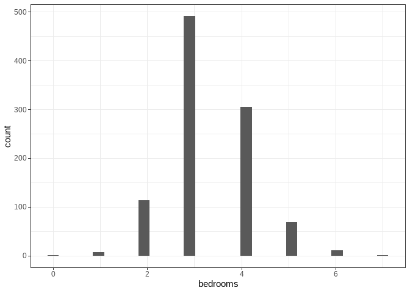

### bathrooms

|  | bathrooms |
| --- | --- |
| Min. | 0 |
| 1st Qu. | 1.5 |
| Median | 2 |
| Mean | 2.0457957957958 |
| 3rd Qu. | 2.5 |
| Max. | 5 |
| NA’s | 1 |
| unique values | 19 |
| class | numeric |

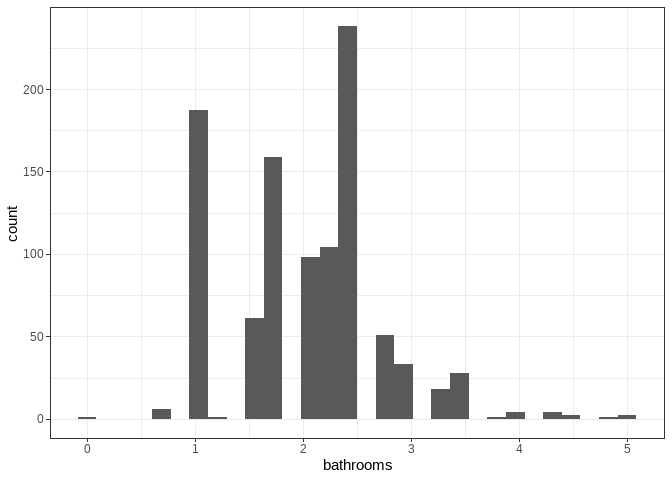

### sqft_living

|  | sqft_living |
| --- | --- |
| Min. | 380 |
| 1st Qu. | 1405 |
| Median | 1900 |
| Mean | 2051.3973973974 |
| 3rd Qu. | 2475 |
| Max. | 6070 |
| NA’s | 1 |
| unique values | 321 |
| class | integer |

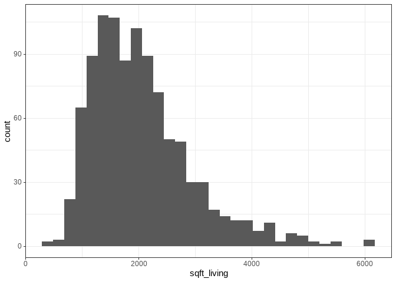

### sqft_lot

|  | sqft_lot |
| --- | --- |
| Min. | 649 |
| 1st Qu. | 5419 |
| Median | 8040 |
| Mean | 14707.2422422422 |
| 3rd Qu. | 11508.5 |
| Max. | 315374 |
| NA’s | 1 |
| unique values | 828 |
| class | integer |

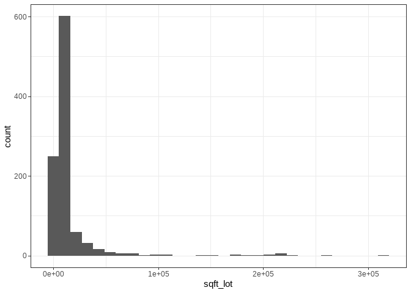

### floors

|  | floors |
| --- | --- |
| Min. | 1 |
| 1st Qu. | 1 |
| Median | 1 |
| Mean | 1.44694694694695 |
| 3rd Qu. | 2 |
| Max. | 3.5 |
| NA’s | 1 |
| unique values | 6 |
| class | numeric |

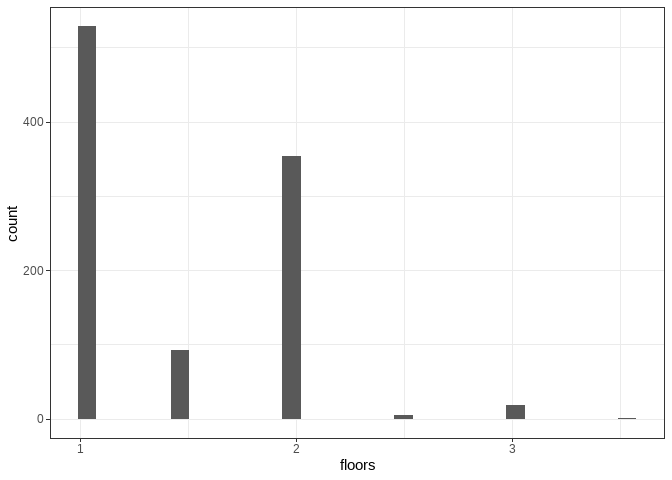

### waterfront

|  | waterfront |
| --- | --- |
| Min. | 0 |
| 1st Qu. | 0 |
| Median | 0 |
| Mean | 0.00800800800800801 |
| 3rd Qu. | 0 |
| Max. | 1 |
| NA’s | 1 |
| unique values | 2 |
| class | integer |

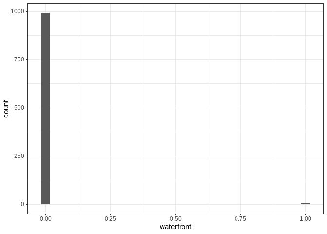

### view

|  | view |
| --- | --- |
| Min. | 0 |
| 1st Qu. | 0 |
| Median | 0 |
| Mean | 0.237237237237237 |
| 3rd Qu. | 0 |
| Max. | 4 |
| NA’s | 1 |
| unique values | 5 |
| class | integer |

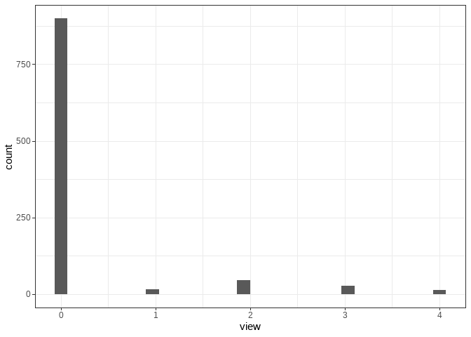

### condition

|  | condition |
| --- | --- |
| Min. | 1 |
| 1st Qu. | 3 |
| Median | 3 |
| Mean | 3.46446446446446 |
| 3rd Qu. | 4 |
| Max. | 5 |
| NA’s | 1 |
| unique values | 5 |
| class | integer |

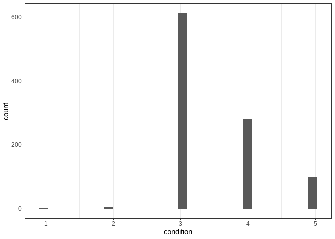

### grade

|  | grade |
| --- | --- |
| Min. | 4 |
| 1st Qu. | 7 |
| Median | 7 |
| Mean | 7.60560560560561 |
| 3rd Qu. | 8 |
| Max. | 12 |
| NA’s | 1 |
| unique values | 9 |
| class | integer |

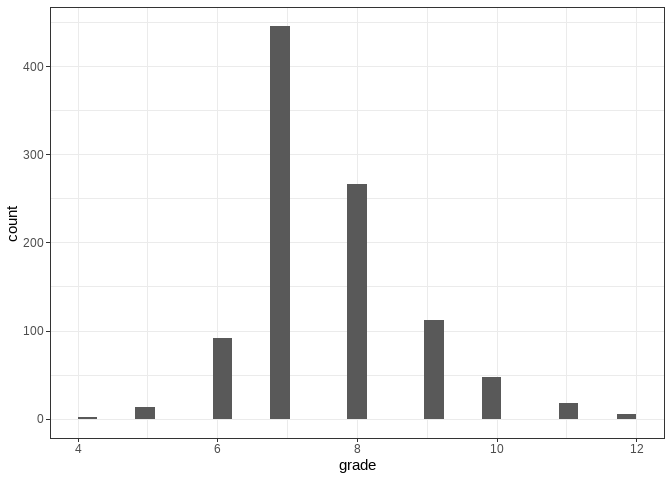

### sqft_above

|  | sqft_above |
| --- | --- |
| Min. | 380 |
| 1st Qu. | 1190 |
| Median | 1540 |
| Mean | 1750.23323323323 |
| 3rd Qu. | 2135 |
| Max. | 6070 |
| NA’s | 1 |
| unique values | 291 |
| class | integer |

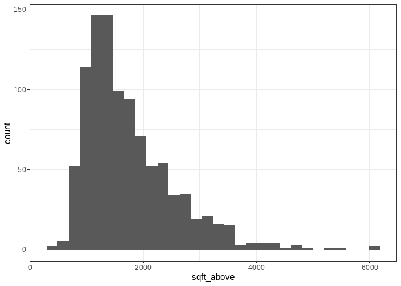

### sqft_basement

|  | sqft_basement |
| --- | --- |
| Min. | 0 |
| 1st Qu. | 0 |
| Median | 0 |
| Mean | 301.164164164164 |
| 3rd Qu. | 580 |
| Max. | 2060 |
| NA’s | 1 |
| unique values | 140 |
| class | integer |

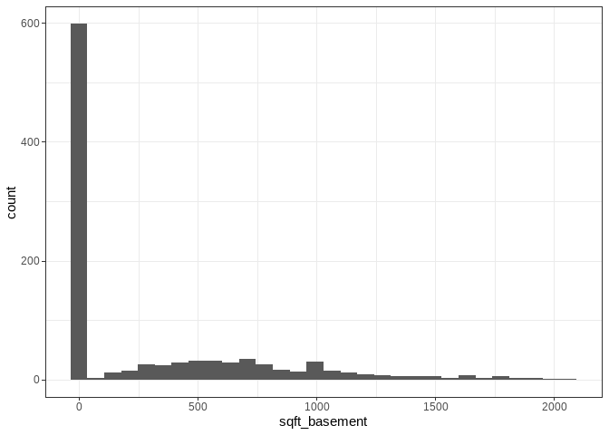

### yr_built

|  | yr_built |
| --- | --- |
| Min. | 1900 |
| 1st Qu. | 1952 |
| Median | 1974 |
| Mean | 1969.03003003003 |
| 3rd Qu. | 1992 |
| Max. | 2015 |
| NA’s | 1 |
| unique values | 114 |
| class | integer |

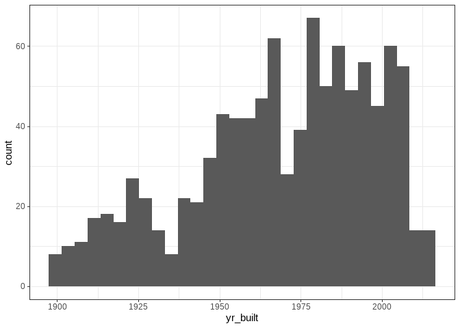

### yr_renovated

|  | yr_renovated |
| --- | --- |
| Min. | 0 |
| 1st Qu. | 0 |
| Median | 0 |
| Mean | 81.8308308308308 |
| 3rd Qu. | 0 |
| Max. | 2014 |
| NA’s | 1 |
| unique values | 25 |
| class | integer |

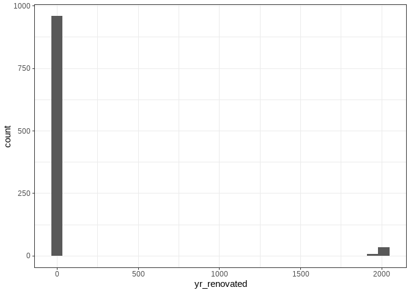

### zipcode

|  | zipcode |
| --- | --- |
| Min. | 98001 |
| 1st Qu. | 98032 |
| Median | 98058 |
| Mean | 98074.4414414414 |
| 3rd Qu. | 98116 |
| Max. | 98199 |
| NA’s | 1 |
| unique values | 69 |
| class | integer |

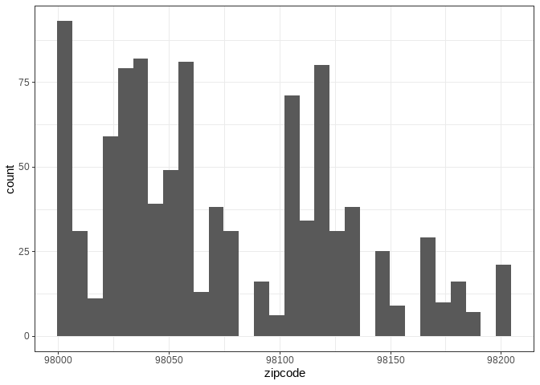

### lat

|  | lat |
| --- | --- |
| Min. | 47.1775 |
| 1st Qu. | 47.443 |
| Median | 47.5636 |
| Mean | 47.5497199199199 |
| 3rd Qu. | 47.6734 |
| Max. | 47.7776 |
| NA’s | 1 |
| unique values | 895 |
| class | numeric |

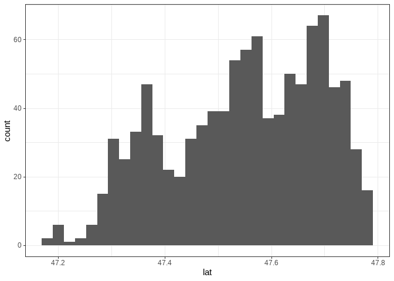

### long

|  | long |
| --- | --- |
| Min. | -122.49 |
| 1st Qu. | -122.3225 |
| Median | -122.218 |
| Mean | -122.207406406406 |
| 3rd Qu. | -122.118 |
| Max. | -121.709 |
| NA’s | 1 |
| unique values | 405 |
| class | numeric |

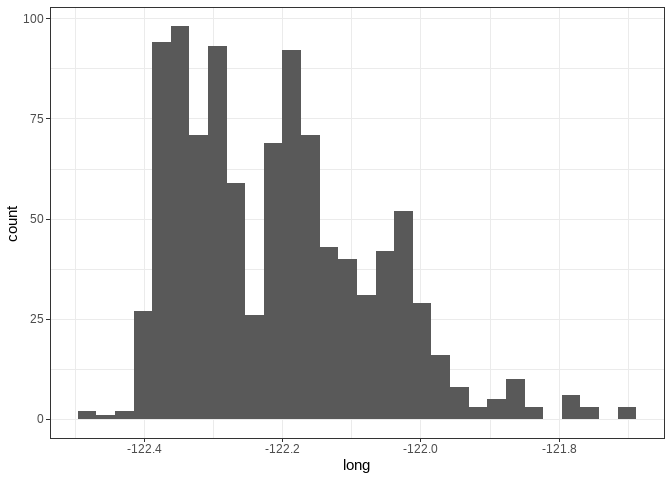

### sqft_living15

|  | sqft_living15 |
| --- | --- |
| Min. | 830 |
| 1st Qu. | 1490 |
| Median | 1850 |
| Mean | 1986.81381381381 |
| 3rd Qu. | 2360 |
| Max. | 4760 |
| NA’s | 1 |
| unique values | 267 |
| class | integer |

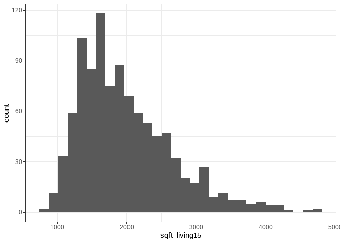

### price

|  | price |
| --- | --- |
| Min. | 8 |
| 1st Qu. | 30.98 |
| Median | 43.5 |
| Mean | 52.0714518518519 |
| 3rd Qu. | 63.44625 |
| Max. | 308 |
| NA’s | 1 |
| unique values | 580 |
| class | numeric |

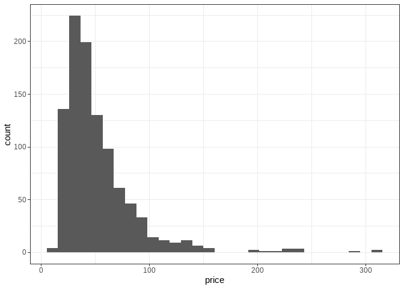

## Searching 4 interesting boxplot relations with outliers

### bedrooms & price

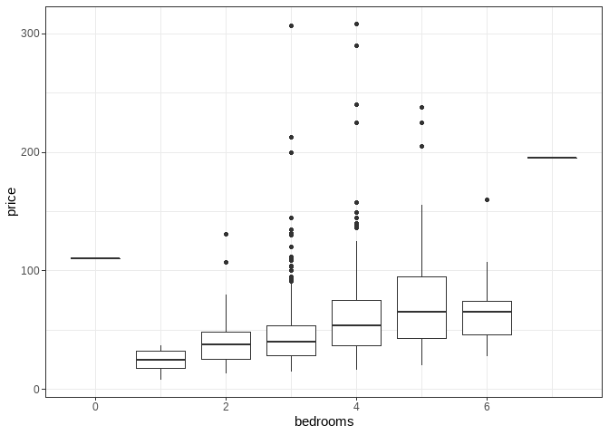

### grade & sqft_living

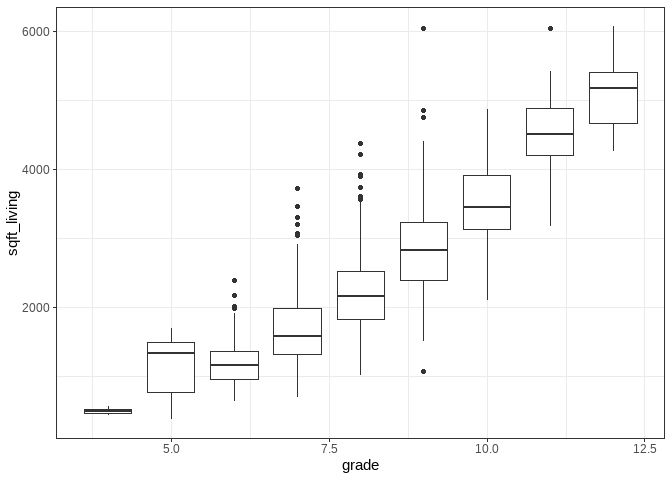

### condition & sqft_living

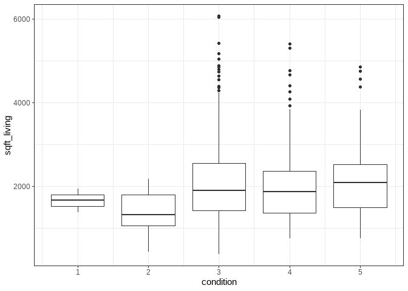

### grade & price

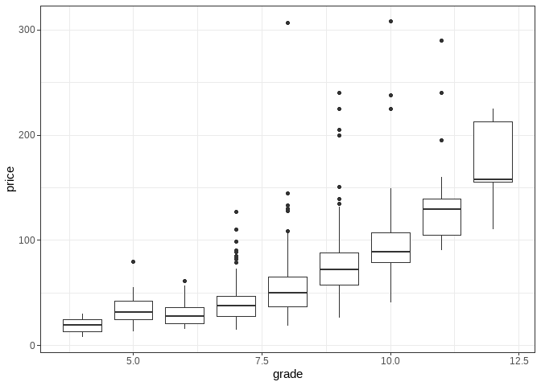

## Searching 4 interesting dependencies

### yr_built & price

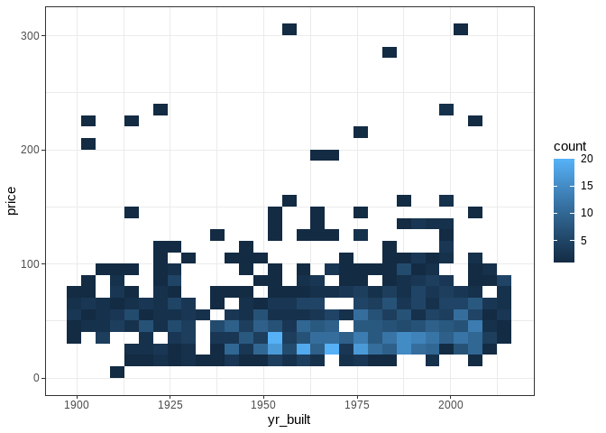

### lat & long

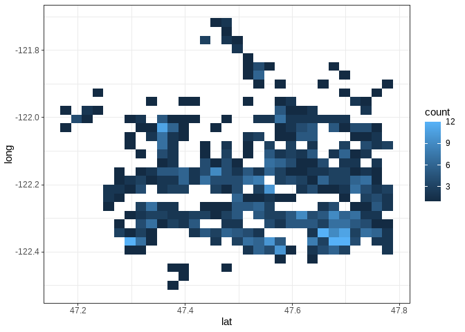

### sqft_above & price

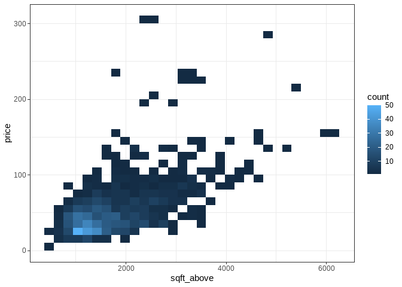

### sqft_living & bathrooms

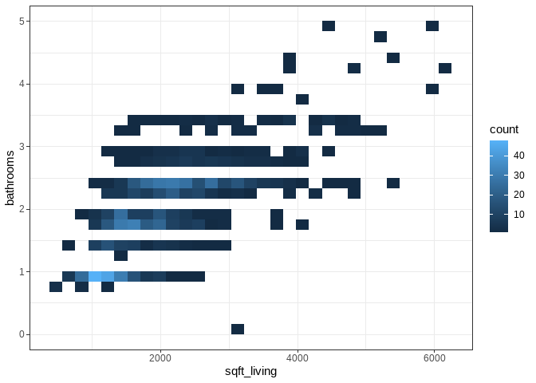

## Searching Pearson’s correlation

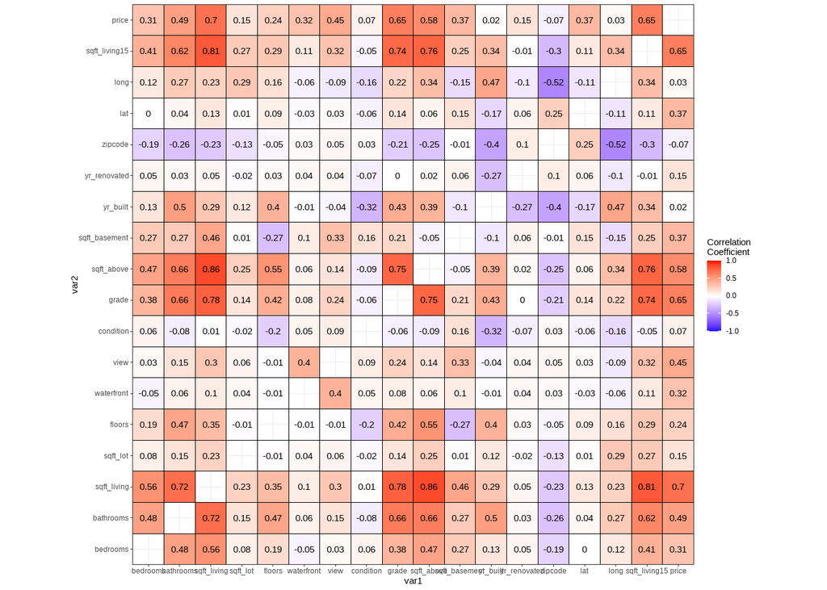

## Conclusions

- The bigger a house, the better grade in the King County scale but actually the biggest houses have condition marked as 3. (boxplots assumption)
- Houses with 3 bedrooms seems to be a potential investment because of multiple outliers in price, while houses with 2 bedrooms seems to be a safe option while purchasing - low risk of overpaying. (boxplot assumption)
- There is the biggest number of offers nearby 9716 Fremont Avenue North in Seattle. (bin2d assumption)
- There is an interesting offer of a house where square footage without basement is more than 4500 and the price is less than 100000$. (bin2d assumption)
- There are a few weak Pearson’s correlations but they do not describe surprising outcomes. For example, it was rather obvious that sqft_living and sqft_above or zipcode and long are quite correlated. Grade and square footage of a house seems to be correlated so the conclusion might be that the King County scale of gradation underestimate smaller houses and they could be differentials for investors in Seattle.

**Comment**: Yeah, I know that in the ‘Variable list’ tables should be next to histograms (spent a lot of time trying to do it), but it is only possible while using a plain R Markdown html format (at least not while using ‘prettydoc’). So I had a choice: a) use ‘prettydoc’ or b) tables next to plots. I picked a) because of my personal sense of aesthetics - the blue-green gradient in the header suits perfectly for real-estate topic and it convinced me the most :)